# Risk Factor Analysis

## Outcome Variable

**Outcome Variable:** ever_stunted

## Predictor Variables

**Intervention Variable:** birthlen

**Adjustment Set:**

- arm
- W_mage
- meducyrs
- feducyrs
- vagbrth
- single
- brthmon
- W_parity
- delta_W_mage
- delta_meducyrs
- delta_feducyrs
- delta_vagbrth
- delta_single
- delta_brthmon
- delta_W_parity

## Stratifying Variables

The analysis was stratified on these variable(s):

- agecat
- studyid
- country

## Data Summary

| agecat | studyid | country | birthlen | ever_stunted | n_cell | n |
| --- | --- | --- | --- | --- | --- | --- |
| 0-24 months (no birth st.) | CMC-V-BCS-2002 | INDIA | >=50 cm | 0 | 4 | 86 |
| 0-24 months (no birth st.) | CMC-V-BCS-2002 | INDIA | >=50 cm | 1 | 12 | 86 |
| 0-24 months (no birth st.) | CMC-V-BCS-2002 | INDIA | <48 cm | 0 | 2 | 86 |
| 0-24 months (no birth st.) | CMC-V-BCS-2002 | INDIA | <48 cm | 1 | 28 | 86 |
| 0-24 months (no birth st.) | CMC-V-BCS-2002 | INDIA | [48-50) cm | 0 | 5 | 86 |
| 0-24 months (no birth st.) | CMC-V-BCS-2002 | INDIA | [48-50) cm | 1 | 35 | 86 |
| 0-24 months (no birth st.) | CMIN | BANGLADESH | >=50 cm | 0 | 2 | 17 |
| 0-24 months (no birth st.) | CMIN | BANGLADESH | >=50 cm | 1 | 0 | 17 |
| 0-24 months (no birth st.) | CMIN | BANGLADESH | <48 cm | 0 | 4 | 17 |
| 0-24 months (no birth st.) | CMIN | BANGLADESH | <48 cm | 1 | 3 | 17 |
| 0-24 months (no birth st.) | CMIN | BANGLADESH | [48-50) cm | 0 | 4 | 17 |
| 0-24 months (no birth st.) | CMIN | BANGLADESH | [48-50) cm | 1 | 4 | 17 |
| 0-24 months (no birth st.) | COHORTS | GUATEMALA | >=50 cm | 0 | 174 | 802 |
| 0-24 months (no birth st.) | COHORTS | GUATEMALA | >=50 cm | 1 | 263 | 802 |
| 0-24 months (no birth st.) | COHORTS | GUATEMALA | <48 cm | 0 | 13 | 802 |
| 0-24 months (no birth st.) | COHORTS | GUATEMALA | <48 cm | 1 | 100 | 802 |
| 0-24 months (no birth st.) | COHORTS | GUATEMALA | [48-50) cm | 0 | 47 | 802 |
| 0-24 months (no birth st.) | COHORTS | GUATEMALA | [48-50) cm | 1 | 205 | 802 |
| 0-24 months (no birth st.) | COHORTS | INDIA | >=50 cm | 0 | 1267 | 5848 |
| 0-24 months (no birth st.) | COHORTS | INDIA | >=50 cm | 1 | 159 | 5848 |
| 0-24 months (no birth st.) | COHORTS | INDIA | <48 cm | 0 | 1082 | 5848 |
| 0-24 months (no birth st.) | COHORTS | INDIA | <48 cm | 1 | 900 | 5848 |
| 0-24 months (no birth st.) | COHORTS | INDIA | [48-50) cm | 0 | 1822 | 5848 |
| 0-24 months (no birth st.) | COHORTS | INDIA | [48-50) cm | 1 | 618 | 5848 |
| 0-24 months (no birth st.) | COHORTS | PHILIPPINES | >=50 cm | 0 | 538 | 2863 |
| 0-24 months (no birth st.) | COHORTS | PHILIPPINES | >=50 cm | 1 | 591 | 2863 |
| 0-24 months (no birth st.) | COHORTS | PHILIPPINES | <48 cm | 0 | 88 | 2863 |
| 0-24 months (no birth st.) | COHORTS | PHILIPPINES | <48 cm | 1 | 487 | 2863 |
| 0-24 months (no birth st.) | COHORTS | PHILIPPINES | [48-50) cm | 0 | 327 | 2863 |
| 0-24 months (no birth st.) | COHORTS | PHILIPPINES | [48-50) cm | 1 | 832 | 2863 |

[output cut: 438 more lines]

The following strata were considered:

- agecat: 0-24 months (no birth st.), studyid: CMC-V-BCS-2002, country: INDIA
- agecat: 0-24 months (no birth st.), studyid: CMIN, country: BANGLADESH
- agecat: 0-24 months (no birth st.), studyid: COHORTS, country: GUATEMALA
- agecat: 0-24 months (no birth st.), studyid: COHORTS, country: INDIA
- agecat: 0-24 months (no birth st.), studyid: COHORTS, country: PHILIPPINES
- agecat: 0-24 months (no birth st.), studyid: CONTENT, country: PERU
- agecat: 0-24 months (no birth st.), studyid: EE, country: PAKISTAN
- agecat: 0-24 months (no birth st.), studyid: GMS-Nepal, country: NEPAL
- agecat: 0-24 months (no birth st.), studyid: IRC, country: INDIA
- agecat: 0-24 months (no birth st.), studyid: JiVitA-3, country: BANGLADESH
- agecat: 0-24 months (no birth st.), studyid: JiVitA-4, country: BANGLADESH
- agecat: 0-24 months (no birth st.), studyid: Keneba, country: GAMBIA
- agecat: 0-24 months (no birth st.), studyid: MAL-ED, country: BANGLADESH
- agecat: 0-24 months (no birth st.), studyid: MAL-ED, country: BRAZIL
- agecat: 0-24 months (no birth st.), studyid: MAL-ED, country: INDIA
- agecat: 0-24 months (no birth st.), studyid: MAL-ED, country: NEPAL
- agecat: 0-24 months (no birth st.), studyid: MAL-ED, country: PERU
- agecat: 0-24 months (no birth st.), studyid: MAL-ED, country: SOUTH AFRICA
- agecat: 0-24 months (no birth st.), studyid: MAL-ED, country: TANZANIA, UNITED REPUBLIC OF
- agecat: 0-24 months (no birth st.), studyid: NIH-Birth, country: BANGLADESH
- agecat: 0-24 months (no birth st.), studyid: NIH-Crypto, country: BANGLADESH
- agecat: 0-24 months (no birth st.), studyid: PROBIT, country: BELARUS
- agecat: 0-24 months (no birth st.), studyid: PROVIDE, country: BANGLADESH
- agecat: 0-24 months (no birth st.), studyid: ResPak, country: PAKISTAN
- agecat: 0-24 months (no birth st.), studyid: SAS-CompFeed, country: INDIA
- agecat: 0-24 months (no birth st.), studyid: ZVITAMBO, country: ZIMBABWE
- agecat: 0-6 months (no birth st.), studyid: CMC-V-BCS-2002, country: INDIA
- agecat: 0-6 months (no birth st.), studyid: CMIN, country: BANGLADESH
- agecat: 0-6 months (no birth st.), studyid: COHORTS, country: GUATEMALA
- agecat: 0-6 months (no birth st.), studyid: COHORTS, country: INDIA
- agecat: 0-6 months (no birth st.), studyid: COHORTS, country: PHILIPPINES
- agecat: 0-6 months (no birth st.), studyid: CONTENT, country: PERU
- agecat: 0-6 months (no birth st.), studyid: EE, country: PAKISTAN
- agecat: 0-6 months (no birth st.), studyid: GMS-Nepal, country: NEPAL
- agecat: 0-6 months (no birth st.), studyid: IRC, country: INDIA
- agecat: 0-6 months (no birth st.), studyid: JiVitA-3, country: BANGLADESH
- agecat: 0-6 months (no birth st.), studyid: JiVitA-4, country: BANGLADESH
- agecat: 0-6 months (no birth st.), studyid: Keneba, country: GAMBIA
- agecat: 0-6 months (no birth st.), studyid: MAL-ED, country: BANGLADESH
- agecat: 0-6 months (no birth st.), studyid: MAL-ED, country: BRAZIL
- agecat: 0-6 months (no birth st.), studyid: MAL-ED, country: INDIA
- agecat: 0-6 months (no birth st.), studyid: MAL-ED, country: NEPAL
- agecat: 0-6 months (no birth st.), studyid: MAL-ED, country: PERU
- agecat: 0-6 months (no birth st.), studyid: MAL-ED, country: SOUTH AFRICA
- agecat: 0-6 months (no birth st.), studyid: MAL-ED, country: TANZANIA, UNITED REPUBLIC OF
- agecat: 0-6 months (no birth st.), studyid: NIH-Birth, country: BANGLADESH
- agecat: 0-6 months (no birth st.), studyid: NIH-Crypto, country: BANGLADESH
- agecat: 0-6 months (no birth st.), studyid: PROBIT, country: BELARUS
- agecat: 0-6 months (no birth st.), studyid: PROVIDE, country: BANGLADESH
- agecat: 0-6 months (no birth st.), studyid: ResPak, country: PAKISTAN
- agecat: 0-6 months (no birth st.), studyid: SAS-CompFeed, country: INDIA
- agecat: 0-6 months (no birth st.), studyid: ZVITAMBO, country: ZIMBABWE
- agecat: 6-24 months, studyid: CMC-V-BCS-2002, country: INDIA
- agecat: 6-24 months, studyid: CMIN, country: BANGLADESH
- agecat: 6-24 months, studyid: COHORTS, country: GUATEMALA
- agecat: 6-24 months, studyid: COHORTS, country: INDIA
- agecat: 6-24 months, studyid: COHORTS, country: PHILIPPINES
- agecat: 6-24 months, studyid: CONTENT, country: PERU
- agecat: 6-24 months, studyid: EE, country: PAKISTAN
- agecat: 6-24 months, studyid: GMS-Nepal, country: NEPAL
- agecat: 6-24 months, studyid: IRC, country: INDIA
- agecat: 6-24 months, studyid: JiVitA-3, country: BANGLADESH
- agecat: 6-24 months, studyid: JiVitA-4, country: BANGLADESH
- agecat: 6-24 months, studyid: Keneba, country: GAMBIA
- agecat: 6-24 months, studyid: MAL-ED, country: BANGLADESH
- agecat: 6-24 months, studyid: MAL-ED, country: BRAZIL
- agecat: 6-24 months, studyid: MAL-ED, country: INDIA
- agecat: 6-24 months, studyid: MAL-ED, country: NEPAL
- agecat: 6-24 months, studyid: MAL-ED, country: PERU
- agecat: 6-24 months, studyid: MAL-ED, country: SOUTH AFRICA
- agecat: 6-24 months, studyid: MAL-ED, country: TANZANIA, UNITED REPUBLIC OF
- agecat: 6-24 months, studyid: NIH-Birth, country: BANGLADESH
- agecat: 6-24 months, studyid: NIH-Crypto, country: BANGLADESH
- agecat: 6-24 months, studyid: PROBIT, country: BELARUS
- agecat: 6-24 months, studyid: PROVIDE, country: BANGLADESH
- agecat: 6-24 months, studyid: ResPak, country: PAKISTAN
- agecat: 6-24 months, studyid: SAS-CompFeed, country: INDIA
- agecat: 6-24 months, studyid: ZVITAMBO, country: ZIMBABWE

### Dropped Strata

Some strata were dropped due to rare outcomes:

- agecat: 0-24 months (no birth st.), studyid: CMC-V-BCS-2002, country: INDIA
- agecat: 0-24 months (no birth st.), studyid: CMIN, country: BANGLADESH
- agecat: 0-24 months (no birth st.), studyid: CONTENT, country: PERU
- agecat: 0-24 months (no birth st.), studyid: MAL-ED, country: BRAZIL
- agecat: 0-24 months (no birth st.), studyid: MAL-ED, country: INDIA
- agecat: 0-24 months (no birth st.), studyid: MAL-ED, country: NEPAL
- agecat: 0-24 months (no birth st.), studyid: MAL-ED, country: TANZANIA, UNITED REPUBLIC OF
- agecat: 0-24 months (no birth st.), studyid: ResPak, country: PAKISTAN
- agecat: 0-6 months (no birth st.), studyid: CMIN, country: BANGLADESH
- agecat: 0-6 months (no birth st.), studyid: CONTENT, country: PERU
- agecat: 0-6 months (no birth st.), studyid: EE, country: PAKISTAN
- agecat: 0-6 months (no birth st.), studyid: MAL-ED, country: BANGLADESH
- agecat: 0-6 months (no birth st.), studyid: MAL-ED, country: BRAZIL
- agecat: 0-6 months (no birth st.), studyid: MAL-ED, country: INDIA
- agecat: 0-6 months (no birth st.), studyid: MAL-ED, country: NEPAL
- agecat: 0-6 months (no birth st.), studyid: MAL-ED, country: TANZANIA, UNITED REPUBLIC OF
- agecat: 0-6 months (no birth st.), studyid: NIH-Crypto, country: BANGLADESH
- agecat: 0-6 months (no birth st.), studyid: PROVIDE, country: BANGLADESH
- agecat: 0-6 months (no birth st.), studyid: ResPak, country: PAKISTAN
- agecat: 6-24 months, studyid: CMC-V-BCS-2002, country: INDIA
- agecat: 6-24 months, studyid: CMIN, country: BANGLADESH
- agecat: 6-24 months, studyid: CONTENT, country: PERU
- agecat: 6-24 months, studyid: MAL-ED, country: BRAZIL
- agecat: 6-24 months, studyid: MAL-ED, country: INDIA
- agecat: 6-24 months, studyid: MAL-ED, country: NEPAL
- agecat: 6-24 months, studyid: MAL-ED, country: SOUTH AFRICA
- agecat: 6-24 months, studyid: MAL-ED, country: TANZANIA, UNITED REPUBLIC OF
- agecat: 6-24 months, studyid: ResPak, country: PAKISTAN

## Methods Detail

We’re interested in the causal parameters $E[Y_a]$ for all values of $a \in \mathcal{A}$. These parameters represent the mean outcome if, possibly contrary to fact, we intervened to set all units to have $A=a$. Under the randomization and positivity assumptions, these are identified by the statistical parameters $\psi_a=E_W[E_{Y|A,W}(Y|A=a,W)]$. In addition, we’re interested in the mean of $Y$, $E[Y]$ under no intervention (the observed mean). We will estimate these parameters by using SuperLearner to fit the relevant likelihood factors – $E_{Y|A,W}(Y|A=a,W)$ and $p(A=a|W)$, and then updating our likelihood fit using a joint TMLE.

For unadjusted analyses ($W=\{\}$), initial likelihoods were estimated using Lrnr_glm to estimate the simple $E(Y|A)$ and Lrnr_mean to estimate $p(A)$. For adjusted analyses, a small library containing Lrnr_glmnet, Lrnr_xgboost, and Lrnr_mean was used.

Having estimated these parameters, we will then use the delta method to estimate relative risks and attributable risks relative to a prespecified baseline level of $A$.

# Results Detail

## Results Plots

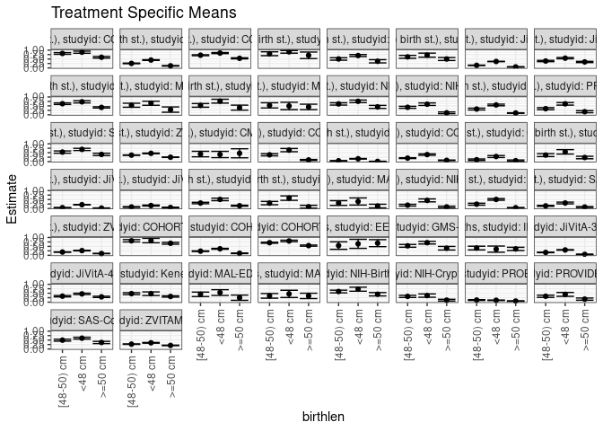

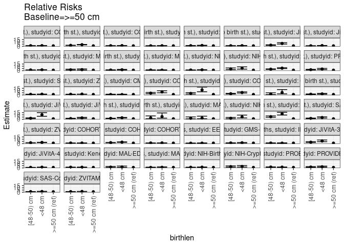

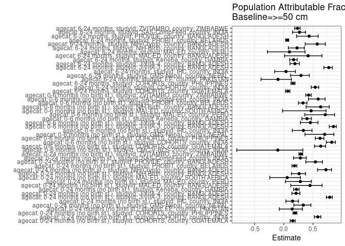

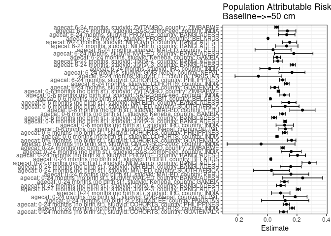

## Results Table

### Parameter: TSM

| agecat | studyid | country | intervention_level | baseline_level | estimate | ci_lower | ci_upper |
| --- | --- | --- | --- | --- | --- | --- | --- |
| 0-24 months (no birth st.) | COHORTS | GUATEMALA | >=50 cm | NA | 0.5991276 | 0.5530447 | 0.6452105 |
| 0-24 months (no birth st.) | COHORTS | GUATEMALA | <48 cm | NA | 0.8836863 | 0.8250159 | 0.9423568 |
| 0-24 months (no birth st.) | COHORTS | GUATEMALA | [48-50) cm | NA | 0.8132919 | 0.7652065 | 0.8613774 |
| 0-24 months (no birth st.) | COHORTS | INDIA | >=50 cm | NA | 0.1194231 | 0.1025402 | 0.1363060 |
| 0-24 months (no birth st.) | COHORTS | INDIA | <48 cm | NA | 0.4420572 | 0.4202602 | 0.4638543 |
| 0-24 months (no birth st.) | COHORTS | INDIA | [48-50) cm | NA | 0.2543306 | 0.2371769 | 0.2714844 |
| 0-24 months (no birth st.) | COHORTS | PHILIPPINES | >=50 cm | NA | 0.5384813 | 0.5099335 | 0.5670292 |
| 0-24 months (no birth st.) | COHORTS | PHILIPPINES | <48 cm | NA | 0.8342171 | 0.8046195 | 0.8638147 |
| 0-24 months (no birth st.) | COHORTS | PHILIPPINES | [48-50) cm | NA | 0.7143625 | 0.6885819 | 0.7401431 |
| 0-24 months (no birth st.) | EE | PAKISTAN | >=50 cm | NA | 0.7083333 | 0.5258340 | 0.8908327 |
| 0-24 months (no birth st.) | EE | PAKISTAN | <48 cm | NA | 0.9032258 | 0.8293696 | 0.9770820 |
| 0-24 months (no birth st.) | EE | PAKISTAN | [48-50) cm | NA | 0.7962963 | 0.6884899 | 0.9041027 |
| 0-24 months (no birth st.) | GMS-Nepal | NEPAL | >=50 cm | NA | 0.3736000 | 0.2842566 | 0.4629434 |
| 0-24 months (no birth st.) | GMS-Nepal | NEPAL | <48 cm | NA | 0.6945820 | 0.6375866 | 0.7515775 |
| 0-24 months (no birth st.) | GMS-Nepal | NEPAL | [48-50) cm | NA | 0.5046216 | 0.4361476 | 0.5730955 |
| 0-24 months (no birth st.) | IRC | INDIA | >=50 cm | NA | 0.5017214 | 0.4186396 | 0.5848032 |
| 0-24 months (no birth st.) | IRC | INDIA | <48 cm | NA | 0.7172704 | 0.6042512 | 0.8302897 |
| 0-24 months (no birth st.) | IRC | INDIA | [48-50) cm | NA | 0.6220831 | 0.5408697 | 0.7032965 |
| 0-24 months (no birth st.) | JiVitA-3 | BANGLADESH | >=50 cm | NA | 0.0566876 | 0.0429100 | 0.0704653 |
| 0-24 months (no birth st.) | JiVitA-3 | BANGLADESH | <48 cm | NA | 0.3630884 | 0.3518441 | 0.3743326 |
| 0-24 months (no birth st.) | JiVitA-3 | BANGLADESH | [48-50) cm | NA | 0.1471198 | 0.1362518 | 0.1579877 |
| 0-24 months (no birth st.) | JiVitA-4 | BANGLADESH | >=50 cm | NA | 0.3370451 | 0.3027375 | 0.3713527 |
| 0-24 months (no birth st.) | JiVitA-4 | BANGLADESH | <48 cm | NA | 0.5480063 | 0.5121611 | 0.5838515 |
| 0-24 months (no birth st.) | JiVitA-4 | BANGLADESH | [48-50) cm | NA | 0.3884471 | 0.3517524 | 0.4251417 |
| 0-24 months (no birth st.) | Keneba | GAMBIA | >=50 cm | NA | 0.4144275 | 0.3795435 | 0.4493116 |
| 0-24 months (no birth st.) | Keneba | GAMBIA | <48 cm | NA | 0.7266480 | 0.6657218 | 0.7875742 |
| 0-24 months (no birth st.) | Keneba | GAMBIA | [48-50) cm | NA | 0.6206502 | 0.5780536 | 0.6632469 |
| 0-24 months (no birth st.) | MAL-ED | BANGLADESH | >=50 cm | NA | 0.2907982 | 0.1423855 | 0.4392109 |
| 0-24 months (no birth st.) | MAL-ED | BANGLADESH | <48 cm | NA | 0.6476840 | 0.5329282 | 0.7624399 |
| 0-24 months (no birth st.) | MAL-ED | BANGLADESH | [48-50) cm | NA | 0.5354643 | 0.4234822 | 0.6474464 |

[output cut: 120 more lines]

### Parameter: E(Y)

| agecat | studyid | country | intervention_level | baseline_level | estimate | ci_lower | ci_upper |
| --- | --- | --- | --- | --- | --- | --- | --- |
| 0-24 months (no birth st.) | COHORTS | GUATEMALA | NA | NA | 0.7082294 | 0.6767491 | 0.7397098 |
| 0-24 months (no birth st.) | COHORTS | INDIA | NA | NA | 0.2867647 | 0.2751726 | 0.2983568 |
| 0-24 months (no birth st.) | COHORTS | PHILIPPINES | NA | NA | 0.6671324 | 0.6498678 | 0.6843969 |
| 0-24 months (no birth st.) | EE | PAKISTAN | NA | NA | 0.8285714 | 0.7659176 | 0.8912252 |
| 0-24 months (no birth st.) | GMS-Nepal | NEPAL | NA | NA | 0.5617391 | 0.5211485 | 0.6023298 |
| 0-24 months (no birth st.) | IRC | INDIA | NA | NA | 0.5913043 | 0.5393557 | 0.6432530 |
| 0-24 months (no birth st.) | JiVitA-3 | BANGLADESH | NA | NA | 0.2656094 | 0.2573816 | 0.2738373 |
| 0-24 months (no birth st.) | JiVitA-4 | BANGLADESH | NA | NA | 0.4273585 | 0.4069266 | 0.4477904 |
| 0-24 months (no birth st.) | Keneba | GAMBIA | NA | NA | 0.5296120 | 0.5040796 | 0.5551444 |
| 0-24 months (no birth st.) | MAL-ED | BANGLADESH | NA | NA | 0.5294118 | 0.4576804 | 0.6011431 |
| 0-24 months (no birth st.) | MAL-ED | PERU | NA | NA | 0.5603865 | 0.4926077 | 0.6281653 |
| 0-24 months (no birth st.) | MAL-ED | SOUTH AFRICA | NA | NA | 0.4690265 | 0.3766048 | 0.5614483 |
| 0-24 months (no birth st.) | NIH-Birth | BANGLADESH | NA | NA | 0.6007828 | 0.5582791 | 0.6432864 |
| 0-24 months (no birth st.) | NIH-Crypto | BANGLADESH | NA | NA | 0.3935681 | 0.3560687 | 0.4310676 |
| 0-24 months (no birth st.) | PROBIT | BELARUS | NA | NA | 0.1205488 | 0.1047261 | 0.1363714 |
| 0-24 months (no birth st.) | PROVIDE | BANGLADESH | NA | NA | 0.3759874 | 0.3382238 | 0.4137509 |
| 0-24 months (no birth st.) | SAS-CompFeed | INDIA | NA | NA | 0.5657407 | 0.5074689 | 0.6240126 |
| 0-24 months (no birth st.) | ZVITAMBO | ZIMBABWE | NA | NA | 0.3494034 | 0.3410405 | 0.3577663 |
| 0-6 months (no birth st.) | CMC-V-BCS-2002 | INDIA | NA | NA | 0.4235294 | 0.3178625 | 0.5291963 |
| 0-6 months (no birth st.) | COHORTS | GUATEMALA | NA | NA | 0.2581047 | 0.2278007 | 0.2884088 |
| 0-6 months (no birth st.) | COHORTS | INDIA | NA | NA | 0.0790014 | 0.0720874 | 0.0859154 |
| 0-6 months (no birth st.) | COHORTS | PHILIPPINES | NA | NA | 0.1893119 | 0.1749594 | 0.2036645 |
| 0-6 months (no birth st.) | GMS-Nepal | NEPAL | NA | NA | 0.1739130 | 0.1429052 | 0.2049209 |
| 0-6 months (no birth st.) | IRC | INDIA | NA | NA | 0.3478261 | 0.2974955 | 0.3981566 |
| 0-6 months (no birth st.) | JiVitA-3 | BANGLADESH | NA | NA | 0.1402030 | 0.1340165 | 0.1463895 |
| 0-6 months (no birth st.) | JiVitA-4 | BANGLADESH | NA | NA | 0.0984277 | 0.0855770 | 0.1112784 |
| 0-6 months (no birth st.) | Keneba | GAMBIA | NA | NA | 0.2552757 | 0.2329715 | 0.2775799 |
| 0-6 months (no birth st.) | MAL-ED | PERU | NA | NA | 0.3333333 | 0.2689597 | 0.3977070 |
| 0-6 months (no birth st.) | MAL-ED | SOUTH AFRICA | NA | NA | 0.2566372 | 0.1757463 | 0.3375280 |
| 0-6 months (no birth st.) | NIH-Birth | BANGLADESH | NA | NA | 0.2309198 | 0.1943452 | 0.2674943 |
| 0-6 months (no birth st.) | PROBIT | BELARUS | NA | NA | 0.0614448 | 0.0507274 | 0.0721623 |
| 0-6 months (no birth st.) | SAS-CompFeed | INDIA | NA | NA | 0.1946247 | 0.1703263 | 0.2189230 |
| 0-6 months (no birth st.) | ZVITAMBO | ZIMBABWE | NA | NA | 0.1729137 | 0.1662801 | 0.1795472 |
| 6-24 months | COHORTS | GUATEMALA | NA | NA | 0.7234469 | 0.6841620 | 0.7627318 |
| 6-24 months | COHORTS | INDIA | NA | NA | 0.2424242 | 0.2305635 | 0.2542850 |
| 6-24 months | COHORTS | PHILIPPINES | NA | NA | 0.6465028 | 0.6261291 | 0.6668766 |
| 6-24 months | EE | PAKISTAN | NA | NA | 0.6206897 | 0.4947260 | 0.7466533 |
| 6-24 months | GMS-Nepal | NEPAL | NA | NA | 0.5631313 | 0.5142177 | 0.6120449 |
| 6-24 months | IRC | INDIA | NA | NA | 0.3733333 | 0.3099915 | 0.4366752 |
| 6-24 months | JiVitA-3 | BANGLADESH | NA | NA | 0.2226530 | 0.2124032 | 0.2329029 |
| 6-24 months | JiVitA-4 | BANGLADESH | NA | NA | 0.3663989 | 0.3454886 | 0.3873091 |
| 6-24 months | Keneba | GAMBIA | NA | NA | 0.3816288 | 0.3523153 | 0.4109422 |
| 6-24 months | MAL-ED | BANGLADESH | NA | NA | 0.4275362 | 0.3446947 | 0.5103778 |
| 6-24 months | MAL-ED | PERU | NA | NA | 0.3884298 | 0.3012257 | 0.4756338 |
| 6-24 months | NIH-Birth | BANGLADESH | NA | NA | 0.5727273 | 0.5192737 | 0.6261808 |
| 6-24 months | NIH-Crypto | BANGLADESH | NA | NA | 0.2628458 | 0.2244546 | 0.3012371 |
| 6-24 months | PROBIT | BELARUS | NA | NA | 0.0642659 | 0.0526827 | 0.0758490 |
| 6-24 months | PROVIDE | BANGLADESH | NA | NA | 0.3004386 | 0.2583143 | 0.3425629 |
| 6-24 months | SAS-CompFeed | INDIA | NA | NA | 0.5006242 | 0.4555100 | 0.5457384 |
| 6-24 months | ZVITAMBO | ZIMBABWE | NA | NA | 0.2627189 | 0.2533027 | 0.2721352 |

### Parameter: RR

| agecat | studyid | country | intervention_level | baseline_level | estimate | ci_lower | ci_upper |
| --- | --- | --- | --- | --- | --- | --- | --- |
| 0-24 months (no birth st.) | COHORTS | GUATEMALA | >=50 cm | >=50 cm | 1.0000000 | 1.0000000 | 1.000000 |
| 0-24 months (no birth st.) | COHORTS | GUATEMALA | <48 cm | >=50 cm | 1.4749551 | 1.3323630 | 1.632808 |
| 0-24 months (no birth st.) | COHORTS | GUATEMALA | [48-50) cm | >=50 cm | 1.3574602 | 1.2318128 | 1.495924 |
| 0-24 months (no birth st.) | COHORTS | INDIA | >=50 cm | >=50 cm | 1.0000000 | 1.0000000 | 1.000000 |
| 0-24 months (no birth st.) | COHORTS | INDIA | <48 cm | >=50 cm | 3.7016054 | 3.1886017 | 4.297145 |
| 0-24 months (no birth st.) | COHORTS | INDIA | [48-50) cm | >=50 cm | 2.1296602 | 1.8226642 | 2.488364 |
| 0-24 months (no birth st.) | COHORTS | PHILIPPINES | >=50 cm | >=50 cm | 1.0000000 | 1.0000000 | 1.000000 |
| 0-24 months (no birth st.) | COHORTS | PHILIPPINES | <48 cm | >=50 cm | 1.5492034 | 1.4543148 | 1.650283 |
| 0-24 months (no birth st.) | COHORTS | PHILIPPINES | [48-50) cm | >=50 cm | 1.3266245 | 1.2452492 | 1.413318 |
| 0-24 months (no birth st.) | EE | PAKISTAN | >=50 cm | >=50 cm | 1.0000000 | 1.0000000 | 1.000000 |
| 0-24 months (no birth st.) | EE | PAKISTAN | <48 cm | >=50 cm | 1.2751423 | 0.9731153 | 1.670910 |
| 0-24 months (no birth st.) | EE | PAKISTAN | [48-50) cm | >=50 cm | 1.1241830 | 0.8403017 | 1.503969 |
| 0-24 months (no birth st.) | GMS-Nepal | NEPAL | >=50 cm | >=50 cm | 1.0000000 | 1.0000000 | 1.000000 |
| 0-24 months (no birth st.) | GMS-Nepal | NEPAL | <48 cm | >=50 cm | 1.8591596 | 1.4438056 | 2.394003 |
| 0-24 months (no birth st.) | GMS-Nepal | NEPAL | [48-50) cm | >=50 cm | 1.3507001 | 1.0260591 | 1.778056 |
| 0-24 months (no birth st.) | IRC | INDIA | >=50 cm | >=50 cm | 1.0000000 | 1.0000000 | 1.000000 |
| 0-24 months (no birth st.) | IRC | INDIA | <48 cm | >=50 cm | 1.4296190 | 1.1377650 | 1.796338 |
| 0-24 months (no birth st.) | IRC | INDIA | [48-50) cm | >=50 cm | 1.2398975 | 1.0044582 | 1.530522 |
| 0-24 months (no birth st.) | JiVitA-3 | BANGLADESH | >=50 cm | >=50 cm | 1.0000000 | 1.0000000 | 1.000000 |
| 0-24 months (no birth st.) | JiVitA-3 | BANGLADESH | <48 cm | >=50 cm | 6.4050728 | 5.0312266 | 8.154067 |
| 0-24 months (no birth st.) | JiVitA-3 | BANGLADESH | [48-50) cm | >=50 cm | 2.5952709 | 2.0217266 | 3.331524 |
| 0-24 months (no birth st.) | JiVitA-4 | BANGLADESH | >=50 cm | >=50 cm | 1.0000000 | 1.0000000 | 1.000000 |
| 0-24 months (no birth st.) | JiVitA-4 | BANGLADESH | <48 cm | >=50 cm | 1.6259136 | 1.4393148 | 1.836704 |
| 0-24 months (no birth st.) | JiVitA-4 | BANGLADESH | [48-50) cm | >=50 cm | 1.1525076 | 1.0020694 | 1.325531 |
| 0-24 months (no birth st.) | Keneba | GAMBIA | >=50 cm | >=50 cm | 1.0000000 | 1.0000000 | 1.000000 |
| 0-24 months (no birth st.) | Keneba | GAMBIA | <48 cm | >=50 cm | 1.7533777 | 1.5575989 | 1.973765 |
| 0-24 months (no birth st.) | Keneba | GAMBIA | [48-50) cm | >=50 cm | 1.4976086 | 1.3445811 | 1.668052 |
| 0-24 months (no birth st.) | MAL-ED | BANGLADESH | >=50 cm | >=50 cm | 1.0000000 | 1.0000000 | 1.000000 |
| 0-24 months (no birth st.) | MAL-ED | BANGLADESH | <48 cm | >=50 cm | 2.2272631 | 1.2948739 | 3.831030 |
| 0-24 months (no birth st.) | MAL-ED | BANGLADESH | [48-50) cm | >=50 cm | 1.8413607 | 1.0601352 | 3.198280 |

[output cut: 120 more lines]

### Parameter: PAR

| agecat | studyid | country | intervention_level | baseline_level | estimate | ci_lower | ci_upper |
| --- | --- | --- | --- | --- | --- | --- | --- |
| 0-24 months (no birth st.) | COHORTS | GUATEMALA | >=50 cm | NA | 0.1091018 | 0.0805327 | 0.1376709 |
| 0-24 months (no birth st.) | COHORTS | INDIA | >=50 cm | NA | 0.1673416 | 0.1505620 | 0.1841212 |
| 0-24 months (no birth st.) | COHORTS | PHILIPPINES | >=50 cm | NA | 0.1286510 | 0.1074646 | 0.1498375 |
| 0-24 months (no birth st.) | EE | PAKISTAN | >=50 cm | NA | 0.1202381 | -0.0404240 | 0.2809002 |
| 0-24 months (no birth st.) | GMS-Nepal | NEPAL | >=50 cm | NA | 0.1881391 | 0.1076466 | 0.2686316 |
| 0-24 months (no birth st.) | IRC | INDIA | >=50 cm | NA | 0.0895830 | 0.0266057 | 0.1525602 |
| 0-24 months (no birth st.) | JiVitA-3 | BANGLADESH | >=50 cm | NA | 0.2089218 | 0.1947710 | 0.2230726 |
| 0-24 months (no birth st.) | JiVitA-4 | BANGLADESH | >=50 cm | NA | 0.0903134 | 0.0607150 | 0.1199117 |
| 0-24 months (no birth st.) | Keneba | GAMBIA | >=50 cm | NA | 0.1151844 | 0.0907832 | 0.1395857 |
| 0-24 months (no birth st.) | MAL-ED | BANGLADESH | >=50 cm | NA | 0.2386136 | 0.1031707 | 0.3740565 |
| 0-24 months (no birth st.) | MAL-ED | PERU | >=50 cm | NA | 0.1592835 | 0.0382347 | 0.2803323 |
| 0-24 months (no birth st.) | MAL-ED | SOUTH AFRICA | >=50 cm | NA | 0.0273737 | -0.0939955 | 0.1487429 |
| 0-24 months (no birth st.) | NIH-Birth | BANGLADESH | >=50 cm | NA | 0.1575688 | 0.0862206 | 0.2289170 |
| 0-24 months (no birth st.) | NIH-Crypto | BANGLADESH | >=50 cm | NA | 0.2844006 | 0.2340449 | 0.3347562 |
| 0-24 months (no birth st.) | PROBIT | BELARUS | >=50 cm | NA | 0.0221991 | 0.0177623 | 0.0266359 |
| 0-24 months (no birth st.) | PROVIDE | BANGLADESH | >=50 cm | NA | 0.2038719 | 0.1491713 | 0.2585725 |
| 0-24 months (no birth st.) | SAS-CompFeed | INDIA | >=50 cm | NA | 0.1610234 | 0.0929464 | 0.2291005 |
| 0-24 months (no birth st.) | ZVITAMBO | ZIMBABWE | >=50 cm | NA | 0.1024826 | 0.0911213 | 0.1138439 |
| 0-6 months (no birth st.) | CMC-V-BCS-2002 | INDIA | >=50 cm | NA | -0.0431373 | -0.2731369 | 0.1868624 |
| 0-6 months (no birth st.) | COHORTS | GUATEMALA | >=50 cm | NA | 0.1636814 | 0.1344548 | 0.1929080 |
| 0-6 months (no birth st.) | COHORTS | INDIA | >=50 cm | NA | 0.0649558 | 0.0567619 | 0.0731497 |
| 0-6 months (no birth st.) | COHORTS | PHILIPPINES | >=50 cm | NA | 0.1175012 | 0.1015558 | 0.1334466 |
| 0-6 months (no birth st.) | GMS-Nepal | NEPAL | >=50 cm | NA | 0.1217391 | 0.0775312 | 0.1659471 |
| 0-6 months (no birth st.) | IRC | INDIA | >=50 cm | NA | 0.1169704 | 0.0582914 | 0.1756495 |
| 0-6 months (no birth st.) | JiVitA-3 | BANGLADESH | >=50 cm | NA | 0.1193451 | 0.1103171 | 0.1283731 |
| 0-6 months (no birth st.) | JiVitA-4 | BANGLADESH | >=50 cm | NA | 0.0448841 | 0.0293505 | 0.0604177 |
| 0-6 months (no birth st.) | Keneba | GAMBIA | >=50 cm | NA | 0.1014661 | 0.0797131 | 0.1232192 |
| 0-6 months (no birth st.) | MAL-ED | PERU | >=50 cm | NA | 0.2371795 | 0.1514234 | 0.3229356 |
| 0-6 months (no birth st.) | MAL-ED | SOUTH AFRICA | >=50 cm | NA | 0.1202735 | 0.0262608 | 0.2142862 |
| 0-6 months (no birth st.) | NIH-Birth | BANGLADESH | >=50 cm | NA | 0.1458622 | 0.0976133 | 0.1941111 |
| 0-6 months (no birth st.) | PROBIT | BELARUS | >=50 cm | NA | 0.0202462 | 0.0163368 | 0.0241557 |
| 0-6 months (no birth st.) | SAS-CompFeed | INDIA | >=50 cm | NA | 0.1147599 | 0.0792509 | 0.1502690 |
| 0-6 months (no birth st.) | ZVITAMBO | ZIMBABWE | >=50 cm | NA | 0.0735932 | 0.0651543 | 0.0820320 |
| 6-24 months | COHORTS | GUATEMALA | >=50 cm | NA | 0.0496664 | 0.0226156 | 0.0767172 |
| 6-24 months | COHORTS | INDIA | >=50 cm | NA | 0.1307692 | 0.1144426 | 0.1470958 |
| 6-24 months | COHORTS | PHILIPPINES | >=50 cm | NA | 0.1028023 | 0.0810076 | 0.1245969 |
| 6-24 months | EE | PAKISTAN | >=50 cm | NA | -0.0611285 | -0.2197818 | 0.0975248 |
| 6-24 months | GMS-Nepal | NEPAL | >=50 cm | NA | 0.1662715 | 0.0778542 | 0.2546888 |
| 6-24 months | IRC | INDIA | >=50 cm | NA | 0.0143620 | -0.0515327 | 0.0802566 |
| 6-24 months | JiVitA-3 | BANGLADESH | >=50 cm | NA | 0.1717339 | 0.1545196 | 0.1889482 |
| 6-24 months | JiVitA-4 | BANGLADESH | >=50 cm | NA | 0.0703163 | 0.0404736 | 0.1001590 |
| 6-24 months | Keneba | GAMBIA | >=50 cm | NA | 0.0644396 | 0.0400960 | 0.0887831 |
| 6-24 months | MAL-ED | BANGLADESH | >=50 cm | NA | 0.1783214 | 0.0481570 | 0.3084857 |
| 6-24 months | MAL-ED | PERU | >=50 cm | NA | 0.0378936 | -0.0841247 | 0.1599119 |
| 6-24 months | NIH-Birth | BANGLADESH | >=50 cm | NA | 0.1300742 | 0.0531192 | 0.2070292 |
| 6-24 months | NIH-Crypto | BANGLADESH | >=50 cm | NA | 0.1507454 | 0.1027799 | 0.1987110 |
| 6-24 months | PROBIT | BELARUS | >=50 cm | NA | 0.0038343 | 0.0021650 | 0.0055036 |
| 6-24 months | PROVIDE | BANGLADESH | >=50 cm | NA | 0.1303959 | 0.0741802 | 0.1866116 |
| 6-24 months | SAS-CompFeed | INDIA | >=50 cm | NA | 0.1349476 | 0.0769903 | 0.1929050 |
| 6-24 months | ZVITAMBO | ZIMBABWE | >=50 cm | NA | 0.0618490 | 0.0496549 | 0.0740432 |

### Parameter: PAF

| agecat | studyid | country | intervention_level | baseline_level | estimate | ci_lower | ci_upper |
| --- | --- | --- | --- | --- | --- | --- | --- |
| 0-24 months (no birth st.) | COHORTS | GUATEMALA | >=50 cm | NA | 0.1540487 | 0.1108976 | 0.1951055 |
| 0-24 months (no birth st.) | COHORTS | INDIA | >=50 cm | NA | 0.5835502 | 0.5244798 | 0.6352827 |
| 0-24 months (no birth st.) | COHORTS | PHILIPPINES | >=50 cm | NA | 0.1928418 | 0.1595719 | 0.2247948 |
| 0-24 months (no birth st.) | EE | PAKISTAN | >=50 cm | NA | 0.1451149 | -0.0753561 | 0.3203847 |
| 0-24 months (no birth st.) | GMS-Nepal | NEPAL | >=50 cm | NA | 0.3349226 | 0.1731598 | 0.4650381 |
| 0-24 months (no birth st.) | IRC | INDIA | >=50 cm | NA | 0.1515006 | 0.0365384 | 0.2527452 |
| 0-24 months (no birth st.) | JiVitA-3 | BANGLADESH | >=50 cm | NA | 0.7865753 | 0.7294639 | 0.8316301 |
| 0-24 months (no birth st.) | JiVitA-4 | BANGLADESH | >=50 cm | NA | 0.2113293 | 0.1391968 | 0.2774173 |
| 0-24 months (no birth st.) | Keneba | GAMBIA | >=50 cm | NA | 0.2174884 | 0.1690467 | 0.2631061 |
| 0-24 months (no birth st.) | MAL-ED | BANGLADESH | >=50 cm | NA | 0.4507146 | 0.1205921 | 0.6569118 |
| 0-24 months (no birth st.) | MAL-ED | PERU | >=50 cm | NA | 0.2842387 | 0.0280971 | 0.4728750 |
| 0-24 months (no birth st.) | MAL-ED | SOUTH AFRICA | >=50 cm | NA | 0.0583628 | -0.2396783 | 0.2847494 |
| 0-24 months (no birth st.) | NIH-Birth | BANGLADESH | >=50 cm | NA | 0.2622725 | 0.1312138 | 0.3735606 |
| 0-24 months (no birth st.) | NIH-Crypto | BANGLADESH | >=50 cm | NA | 0.7226209 | 0.5782284 | 0.8175810 |
| 0-24 months (no birth st.) | PROBIT | BELARUS | >=50 cm | NA | 0.1841503 | 0.1400914 | 0.2259519 |
| 0-24 months (no birth st.) | PROVIDE | BANGLADESH | >=50 cm | NA | 0.5422308 | 0.3769964 | 0.6636413 |
| 0-24 months (no birth st.) | SAS-CompFeed | INDIA | >=50 cm | NA | 0.2846241 | 0.1664925 | 0.3860130 |
| 0-24 months (no birth st.) | ZVITAMBO | ZIMBABWE | >=50 cm | NA | 0.2933074 | 0.2602289 | 0.3249069 |
| 0-6 months (no birth st.) | CMC-V-BCS-2002 | INDIA | >=50 cm | NA | -0.1018519 | -0.8043179 | 0.3271266 |
| 0-6 months (no birth st.) | COHORTS | GUATEMALA | >=50 cm | NA | 0.6341666 | 0.5273170 | 0.7168629 |
| 0-6 months (no birth st.) | COHORTS | INDIA | >=50 cm | NA | 0.8222112 | 0.7283155 | 0.8836561 |
| 0-6 months (no birth st.) | COHORTS | PHILIPPINES | >=50 cm | NA | 0.6206752 | 0.5409017 | 0.6865871 |
| 0-6 months (no birth st.) | GMS-Nepal | NEPAL | >=50 cm | NA | 0.7000000 | 0.3631065 | 0.8586891 |
| 0-6 months (no birth st.) | IRC | INDIA | >=50 cm | NA | 0.3362900 | 0.1465752 | 0.4838315 |
| 0-6 months (no birth st.) | JiVitA-3 | BANGLADESH | >=50 cm | NA | 0.8512304 | 0.7797088 | 0.8995311 |
| 0-6 months (no birth st.) | JiVitA-4 | BANGLADESH | >=50 cm | NA | 0.4560108 | 0.2845477 | 0.5863817 |
| 0-6 months (no birth st.) | Keneba | GAMBIA | >=50 cm | NA | 0.3974767 | 0.3107912 | 0.4732592 |
| 0-6 months (no birth st.) | MAL-ED | PERU | >=50 cm | NA | 0.7115385 | 0.3604435 | 0.8698941 |
| 0-6 months (no birth st.) | MAL-ED | SOUTH AFRICA | >=50 cm | NA | 0.4686520 | -0.0208523 | 0.7234363 |
| 0-6 months (no birth st.) | NIH-Birth | BANGLADESH | >=50 cm | NA | 0.6316574 | 0.3833140 | 0.7799913 |
| 0-6 months (no birth st.) | PROBIT | BELARUS | >=50 cm | NA | 0.3295025 | 0.2523095 | 0.3987260 |
| 0-6 months (no birth st.) | SAS-CompFeed | INDIA | >=50 cm | NA | 0.5896475 | 0.4214667 | 0.7089378 |
| 0-6 months (no birth st.) | ZVITAMBO | ZIMBABWE | >=50 cm | NA | 0.4256064 | 0.3769194 | 0.4704890 |
| 6-24 months | COHORTS | GUATEMALA | >=50 cm | NA | 0.0686525 | 0.0297578 | 0.1059879 |
| 6-24 months | COHORTS | INDIA | >=50 cm | NA | 0.5394230 | 0.4714261 | 0.5986726 |
| 6-24 months | COHORTS | PHILIPPINES | >=50 cm | NA | 0.1590128 | 0.1238284 | 0.1927844 |
| 6-24 months | EE | PAKISTAN | >=50 cm | NA | -0.0984848 | -0.3888305 | 0.1311618 |
| 6-24 months | GMS-Nepal | NEPAL | >=50 cm | NA | 0.2952624 | 0.1170787 | 0.4374866 |
| 6-24 months | IRC | INDIA | >=50 cm | NA | 0.0384696 | -0.1553276 | 0.1997588 |
| 6-24 months | JiVitA-3 | BANGLADESH | >=50 cm | NA | 0.7713072 | 0.6874819 | 0.8326484 |
| 6-24 months | JiVitA-4 | BANGLADESH | >=50 cm | NA | 0.1919119 | 0.1067123 | 0.2689854 |
| 6-24 months | Keneba | GAMBIA | >=50 cm | NA | 0.1688540 | 0.1023662 | 0.2304172 |
| 6-24 months | MAL-ED | BANGLADESH | >=50 cm | NA | 0.4170906 | 0.0138663 | 0.6554389 |
| 6-24 months | MAL-ED | PERU | >=50 cm | NA | 0.0975559 | -0.2793123 | 0.3634038 |
| 6-24 months | NIH-Birth | BANGLADESH | >=50 cm | NA | 0.2271137 | 0.0781343 | 0.3520171 |
| 6-24 months | NIH-Crypto | BANGLADESH | >=50 cm | NA | 0.5735127 | 0.3672062 | 0.7125582 |
| 6-24 months | PROBIT | BELARUS | >=50 cm | NA | 0.0596631 | 0.0323738 | 0.0861829 |
| 6-24 months | PROVIDE | BANGLADESH | >=50 cm | NA | 0.4340184 | 0.2191510 | 0.5897604 |
| 6-24 months | SAS-CompFeed | INDIA | >=50 cm | NA | 0.2695588 | 0.1496515 | 0.3725580 |
| 6-24 months | ZVITAMBO | ZIMBABWE | >=50 cm | NA | 0.2354190 | 0.1879474 | 0.2801154 |